# jekyll-jupyter-notebook20261005-3452-6j5097

- Notebook Overview
  - Competition Description
  - Library Imports
- Phase 1
  - Competition Description
  - Overview
  - Data Loading
  - Preprocessing
  - Data Analysis
  - Feature Selection
  - Modelling
  - Outputs and Evaluation
- Phase 2
  - Competition Description
  - Overview
  - Model Loading
  - Model Creation
  - Model Selection
  - Modelling
  - Outputs and Evaluation
- Phase 3
  - Competition Description
  - Overview
  - Merging Best Methods
  - Exploring Location
  - Subgroup Exploration
  - Implementing Further Models

# Notebook Overview

This notebook is part of coursework for the Machine Learning Paradigms module at the University of Bristol. This notebook is accompanied by a report.

## Competition Description

*[Kaggle Link](https://www.kaggle.com/competitions/morebikes2023/overview)*  
The goal of this assignment is to predict the number of available bicycles in all rental stations 3 hours in advance. There are at least two use cases for such predictions. First, a user plans to rent (or return) a bike in 3 hours' time and wants to choose a bike station which is not empty (or full). Second, the company wants to avoid situations where a station is empty or full and therefore needs to move bikes between stations. For this purpose, they need to know which stations are more likely to be empty or full soon.

The assignment will be organised by 3 phases. During each phase you will be given a particular task. You can earn different proportions of the marks by finishing these phases step by step.

## Library Imports

```python
import pandas as pd
import sys
import matplotlib.pyplot as plt
import seaborn as sb
import folium as fl
from folium.plugins import HeatMap
from mlxtend.feature_selection import SequentialFeatureSelector as SFS
from mlxtend.plotting import plot_sequential_feature_selection as plot_sfs
from sklearn.linear_model import LinearRegression
from sklearn.linear_model import Lasso
from sklearn.cluster import KMeans
from sklearn.model_selection import train_test_split
from sklearn.preprocessing import StandardScaler
from sklearn.pipeline import make_pipeline
from sklearn.metrics import r2_score
from PIL import Image
import geopy.distance
from sklearn.tree import DecisionTreeRegressor
from sklearn.tree import plot_tree
import plotly.express as px
```

```python
# Option to suppress warnings
import warnings
pd.set_option('mode.chained_assignment', None)
warnings.simplefilter("ignore", UserWarning)
```

# Phase 1

## Competition Description

In this phase, you will be given the data of 75 stations (Station 201 to Station 275) for the period of one month. The task is to predict availability for each station for the next 3 months.

There are two approaches for this task:

- Train a separate model for each station.
- Train a single model on all stations together.

Implement your models based on both approaches and check which approach is better. Investigate and discuss the results.

## Overview

This phase is broken into the following sections:

In the Data Loading section, functions are created that load station data into a pandas dataframe.  
In the Data Analysis section, the data is visualised and discussed.  
In the Preprocessing section, functions are created to convert the dataframe into a suitable form for modelling.  
In the Feature Selection section, functions are implemented for feature selection.  
In the Modelling section, a linear regression model is fit to the dataframe(s).  
In the Outputs and Evaluation section, functions to perform all tasks are created alongside csv generation and evaluation of the models.

## Data Loading

The below code allows for either station x, or stations x to y to be loaded.  
The function can be called as load_training_data(x) or load_training_data(x, y) where x and y are integers between 1 and 275.

```python
# Function for loading training data, takes either a single station or the start and end number of stations
def load_training_data(first_station: int, last_station=0):
    # Checks values input are integer
    try:
        int(first_station)
        int(last_station)
    except ValueError:
        print("Please input an integer for stations to load")
        sys.exit("Error during load_training_data")
    # If no second station is provided, set last_station to be equal to first_station
    if last_station==0:
        last_station=first_station
    # If the stations are input in incorrectly, output an error
    if last_station<first_station:
        print("Make sure last station is larger or equal to first station")
        sys.exit("Error during load_training_data")
    # Checks if an invalid value is input
    if first_station< 1:
        print("Stations start at 1")
        sys.exit("Error during load_training_data")
    if last_station> 275:
        print("Stations only go up to 275")
        sys.exit("Error during load_training_data")
    #Create an empty dataframe
    df=pd.DataFrame()
    # Iterates over every station
    for i in range(first_station, last_station+1):
        # Enabled all stations to be read if necessary (different format for 1-200 and 201-275)
        if i<=200:
            # Joins the DF with the new loaded station, dropping the index. Stations are added in order of station number.
            df = pd.concat([df, pd.read_csv(f"Train/station_{str(i)}_deploy_full.csv")], ignore_index=True)
        if i>200:
            # Joins the DF with the new loaded station, dropping the index. Stations are added in order of station number.
            df = pd.concat([df, pd.read_csv(f"Train/station_{str(i)}_deploy.csv")], ignore_index=True)
    return df
```

```python
# Uncomment the below code to test
# load_training_data(201, 275)
```

## Preprocessing

As the weekday column is alphanumerical, it needs to be converted to a numerical representation.  
The selected method for this was to create a dataframe column for each weekday and input a 1 in the column representing the weekday to depict this numerically.  
This is essentially a simple vectorisation.

[Chen and Flach (2015)](https://ceur-ws.org/Vol-1526/paper12.pdf) suggested normalising the bikes 3 hours ago, short profile bikes, and short profile 3h diff bikes, by dividing the values by the total number of docks; this has been implemented; this was also extended to include full pofile values. This function manipulates the values in-place.

A function has also been created to normalise the number of bikes by the number of docks, resulting in a percentage output that later can be multiplied by the number of docks for a station to calculate the number of bikes. The normalisation of the target variable's impact can be evaluated through this method as it manipulates the values in-place.

The handle_na function implements ways to handle NA values, at present it drops any NA values until methods are created to handle each column individually.

```python
# Uncomment the below code to see the datatypes in the dataframe
#load_training_data(200).dtypes
```

```python
# Takes a dataframe and creates columns to represent weekdays as numbers
def convert_weekdays(df):
    try:
        # Convert weekdays to lowercase, to prevent potential missed data
        df['weekday'] = df['weekday'].str.lower()

        # Create a column for each weekday and set the value to either 0 or 1, based on if it meets the weekday criteria
        df['monday'] = (df['weekday'] == 'monday').astype(int)
        df['tuesday'] = (df['weekday'] == 'tuesday').astype(int)
        df['wednesday'] = (df['weekday'] == 'wednesday').astype(int)
        df['thursday'] = (df['weekday'] == 'thursday').astype(int)
        df['friday'] = (df['weekday'] == 'friday').astype(int)
        df['saturday'] = (df['weekday'] == 'saturday').astype(int)
        df['sunday'] = (df['weekday'] == 'sunday').astype(int)

        # Drop the weekday column
        df.drop(columns=['weekday'], inplace=True)

        # Fill the NaN values in case an entry didn't have a weekday in it
        df[['monday', 'tuesday', 'wednesday', 'thursday', 'friday', 'saturday', 'sunday' ]] = df[['monday', 'tuesday', 'wednesday', 'thursday', 'friday', 'saturday', 'sunday' ]].fillna(0)
    # If weekdays cannot be found, it outputs an error as all stations should contain this value
    except KeyError:
        print("DataFrame does not contain weekday column")
        sys.exit("Error during convert_weekdays")
    return df
```

```python
# Uncomment the below code to test the above function
# convert_weekdays(load_training_data(200))
```

```python
# Takes a dataframe and normalises the bike profile variables
def normalise_bike_profiles(df):
    try:
        # Divides each column value by the number of docks and stores it in-place
        df['bikes_3h_ago'] = df['bikes_3h_ago']/df['numDocks']
        df['full_profile_3h_diff_bikes'] = df['full_profile_3h_diff_bikes']/df['numDocks']
        df['full_profile_bikes'] = df['full_profile_bikes']/df['numDocks']
        df['short_profile_3h_diff_bikes'] = df['short_profile_3h_diff_bikes']/df['numDocks']
        df['short_profile_bikes'] = df['short_profile_bikes']/df['numDocks']
    # If a column isn't found it returns an error, as all stations should have these values
    except KeyError:
        print("DataFrame does not contain bike profiles columns")
        sys.exit("Error during normalise_bike_profiles")
    return df
```

```python
# Uncomment the below code to test the above function
# normalise_bike_profiles(load_training_data(200))
```

```python
# Takes a dataframe and normalises the bikes
def normalise_bikes(df):
    try:
        # Assumes there are no 0 docks, as that would be a redundant station.
        df['bikes'] = df['bikes']/df['numDocks']
    # If a column isn't found it returns an error, as all stations should have these values
    except KeyError:
        print("DataFrame does not contain bike or docks column(s)")
        sys.exit("Error during normalise_bikes")
    return df
```

```python
# Uncomment the below code to test the above function
# normalise_bikes(load_training_data(200))
```

```python
def handle_na(df):
    return df.dropna()
```

```python
# Uncomment the below code to test the above function
#handle_na(load_training_data(200))
```

```python
# Function to perform all pre-processing steps at once
def preprocessing(df, handlena=True):
    if handlena:
        df = handle_na(df)
    df = convert_weekdays(df)
    df = normalise_bike_profiles(df)
    df = normalise_bikes(df)
    return df
```

```python
# Uncomment the below code to test the above function
# preprocessing(load_training_data(200))
```

## Data Analysis

The below functions can be used to give insight into the dataframe by visualising the correlation of the data, statistically describing the dataframe, providing an average of each station, and producing a geographic map of the stations with of average usage.

```python
# Function to get the correlation of the dataframe, must have a dataframe passed to it. If True is also passed it will output the matrix and save it
def correlation_matrix(df, show=False):
    # Uses pandas corr() to get correlation matrix
    correlation=df.corr()
    # If the function is called to show the function
    if show:
        # Sets figure size
        plt.figure(figsize=(20, 10))
        # Plots the heatmap, with 1 and -1 as boundaries and annotations. FMT rounds the values in the figure
        plot=sb.heatmap(correlation,  cmap="YlGnBu",vmin=-1, vmax=1, annot=True, fmt=".2f")
        # Adds a title
        plot.set_title('Correlation Heatmap', fontdict={'fontsize':18}, pad=12)
        # Saves the map as heatmap.png for later viewing.
        plt.savefig('heatmap.png', dpi=300, bbox_inches='tight')
    return correlation
```

```python
# Uncomment this code to test the above functions
# correlation_matrix(convert_weekdays(load_training_data(201,275)), True)
```

```python
# Function to get numeric descriptions of the dataframe, must have a dataframe passed to it. If True is also passed it will output the data and save it
def describe_dataframe(df, show=False):
    # Uses pandas describe to get numerical values
    description=df.describe(include='all')
    # If the function is called to show the function
    if show:
        # Outputs the dataframe
        print(description)
        # Saves it to a CSV
        description.to_csv("description.csv")
    return description
```

```python
# Uncomment this code to test the above functions
# describe_dataframe(convert_weekdays(load_training_data(201,275)), True)
```

```python
# Function to get averages for stations in the dataframe, must have a dataframe passed to it. If True is also passed it will output the data and save it
def average_bikes(df, show=False):
    # Uses pandas groupby and mean to get the averages for each station
    average=df.groupby('station').mean()
    if show:
        # Outputs the dataframe
        print(average)
        # Saves it to a CSV
        average.to_csv("average.csv")
    return average
```

```python
# Uncomment this code to test the above functions
# average_bikes(convert_weekdays(load_training_data(201,275)), True)
```

```python
# Function to get show a geographical heatmap for stations in the dataframe, must have a dataframe passed to it. If True is also passed it will output the map and save it
def geographic_view(df, show=False):
    # Creates a map in Valencia
    map_view = fl.Map(location=[39.46975, -0.37739], zoom_start=12)

    # Adds markers to the heatmap for every station
    for index, row in df.iterrows():
        fl.Marker([row['latitude'], row['longitude']], popup=f"Average bikes: {row['bikes']}").add_to(map_view)

    # Creates heatmap data for the markers, using green to red for high to low values
    heat_data = [[ row['latitude'], row['longitude'], row['bikes']] for index, row in df.iterrows()]
    HeatMap(heat_data, gradient={0.3: 'green', 0.6: 'yellow', 0.9:'red'}, radius=30, blur=10).add_to(map_view)

    if show:
        # Saves the map
        map_view.save('bike_rental_map.html')
        display(map_view)
    return map_view
```

```python
# Uncomment this code to test the above functions
# geographic_view(average_bikes(preprocessing(load_training_data(201,275)), False))
```

```python
# Function to perform all data_analysis steps at once
def data_analysis(df, show=False):
    correlation_matrix(df, show)
    describe_dataframe(df, show)
    geographic_view(average_bikes(df, show), show)
```

```
            station      latitude     longitude     numDocks     timestamp  \
count  42600.000000  42600.000000  42600.000000  42600.00000  4.260000e+04
mean     238.000000     39.471010     -0.372940     19.56000  1.413765e+09
std       21.648965      0.013061      0.023094      5.70209  5.950482e+05
min      201.000000     39.444093     -0.409316     14.00000  1.412730e+09
25%      219.000000     39.462808     -0.393181     15.00000  1.413251e+09
50%      238.000000     39.469844     -0.375973     20.00000  1.413765e+09
75%      257.000000     39.480591     -0.354640     20.00000  1.414275e+09
max      275.000000     39.495034     -0.328902     40.00000  1.414793e+09

          year    month           day         hour      weekhour  ...  \
count  42600.0  42600.0  42600.000000  42600.00000  42600.000000  ...
mean    2014.0     10.0     19.610915     11.59331     84.593310  ...
std        0.0      0.0      6.873305      6.87920     46.089231  ...
min     2014.0     10.0      8.000000      0.00000      1.000000  ...
25%     2014.0     10.0     14.000000      6.00000     48.000000  ...
50%     2014.0     10.0     20.000000     12.00000     85.000000  ...
75%     2014.0     10.0     26.000000     18.00000    121.000000  ...
max     2014.0     10.0     31.000000     23.00000    168.000000  ...

       short_profile_3h_diff_bikes  short_profile_bikes         bikes  \
count                 42600.000000         42600.000000  42600.000000
mean                      0.000004             0.392049      0.395875
std                       0.219118             0.286342      0.318846
min                      -1.000000             0.000000      0.000000
25%                      -0.087500             0.140351      0.100000
50%                       0.000000             0.350000      0.333333
75%                       0.088889             0.600000      0.666667
max                       1.000000             1.000000      1.000000

             monday       tuesday     wednesday      thursday        friday  \
count  42600.000000  42600.000000  42600.000000  42600.000000  42600.000000
mean       0.126761      0.125000      0.163732      0.167254      0.165493
std        0.332708      0.330723      0.370037      0.373206      0.371629
min        0.000000      0.000000      0.000000      0.000000      0.000000
25%        0.000000      0.000000      0.000000      0.000000      0.000000
50%        0.000000      0.000000      0.000000      0.000000      0.000000
75%        0.000000      0.000000      0.000000      0.000000      0.000000
max        1.000000      1.000000      1.000000      1.000000      1.000000

```

[output cut: 53 more lines]

```
         tuesday  wednesday  thursday    friday  saturday  sunday
station
201        0.125   0.163732  0.167254  0.165493  0.126761   0.125
202        0.125   0.163732  0.167254  0.165493  0.126761   0.125
203        0.125   0.163732  0.167254  0.165493  0.126761   0.125
204        0.125   0.163732  0.167254  0.165493  0.126761   0.125
205        0.125   0.163732  0.167254  0.165493  0.126761   0.125
...          ...        ...       ...       ...       ...     ...
271        0.125   0.163732  0.167254  0.165493  0.126761   0.125
272        0.125   0.163732  0.167254  0.165493  0.126761   0.125
273        0.125   0.163732  0.167254  0.165493  0.126761   0.125
274        0.125   0.163732  0.167254  0.165493  0.126761   0.125
275        0.125   0.163732  0.167254  0.165493  0.126761   0.125

[75 rows x 30 columns]
```

Make this Notebook Trusted to load map: File -> Trust Notebook

[interactive chart not shown]

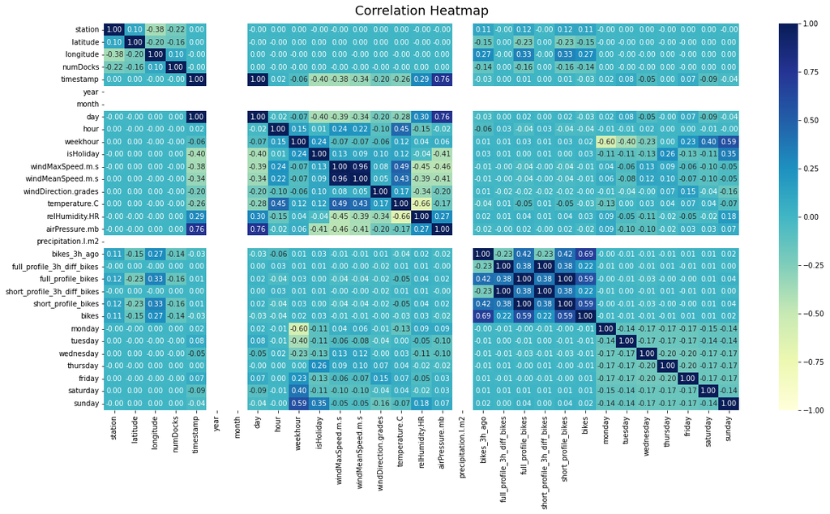

```python
# Uncomment the below code to test the above function
data_analysis(preprocessing(load_training_data(201, 275)), True)
```

## Feature Selection

This section creates feature selection functions; these are feature_filtering using correlation, and feature_wrapping using forward selection; Embedded feature selection can be seen in Modelling with the Lasso method. A function that identifies the selected features of both methods is also created.

```python
# Function that takes a dataframe and optional cutoff point
# Returns all features that have a correlation score above the cutofff point
def feature_filtering(df, cutoff=0.5):
    correlation = correlation_matrix(df, False)
    # uses absolute value to allow for negative correlation
    correlation = correlation[abs((correlation['bikes'])>=cutoff)]
    # Drops the bikes index
    correlation = correlation.drop(['bikes'])
    return correlation.index.tolist()
```

```python
# # Uncomment the below code for testing
# feature_filtering(preprocessing(load_training_data(201, 275)))
```

```python
def feature_wrapping(df, show=False):
    # Creates test and training data out of the passed dataframes
    X = df.drop(columns=['bikes'])
    y = df['bikes']
    X_train, X_test, y_train, y_test= train_test_split(X, y, test_size=0.2, random_state=1)

    # Creates a forward selection using the mlxtend library
    forward = SFS(LinearRegression(), k_features=(1, X.shape[1]), forward=True, floating=False, scoring = 'r2', cv = 0)

    # Creates a scalar pipeline to go through each feature
    pipe = make_pipeline(StandardScaler(), forward)

    # Fits the pipeline to the data
    pipe.fit(X_train, y_train)

    #Outputs a graph of the feature results
    if show:
        fig = plot_sfs(forward.get_metric_dict(), kind='std_dev', figsize=(20,10))
        plt.title('Sequential Forward Selection (w. StdDev)')
        plt.grid()
        plt.show()
        plt.savefig('forward.png', dpi=300, bbox_inches='tight')

    # Goes through each result of the forward selector, identifying the last accuracy score
    # Then checks if the next result has an accuracy score is at least 0.01 bigger
    # this prevents the model from being too greedy with the amount of features.
    feature_indx=[]
    features=[]
    last_avg_score=0
    results_dict=forward.get_metric_dict()
    for i in results_dict:
        if round(results_dict[i]['avg_score'],2) > last_avg_score:
            last_avg_score=round(results_dict[i]['avg_score'],2)
            feature_indx=results_dict[i]['feature_idx']
    for i in feature_indx:
        features.append(X.columns[i])
    return features
```

```python
# Uncomment the below code for testing
# feature_wrapping(preprocessing(load_training_data(201, 275)), True)
```

```python
# A function that combines the results of both feature selection methods
# If greedy = true (default) it combines the union of the lists
# else it returns the intersect
def feature_selection(df, greedy=True, cutoff=0.5):
    wrapping = feature_wrapping(df)
    filtering = feature_filtering(df, cutoff)
    if greedy:
        features=list(set(wrapping+filtering))
    else:
        features = list(set(wrapping) & set(filtering))
    return features
```

```python
# Uncomment the below code for testing
# feature_selection(preprocessing(load_training_data(201, 275)), False)
# feature_selection(preprocessing(load_training_data(201, 275)))
```

## Modelling

This section creates a single function requires a dataframe and the optional arguments of approach, selection, and cutoff. The function will fit the data to either all test values or to each individual station, then will select the features to fit to based on user input. The user can modify the feature filtering approach using the cutoff parameter.

```python
# Defines the function which takes:
# a dataframe for testing (required)
# an approach type (optional), 'single' trains the model on all training data and 'separate' trains the model on each station
# a feature selection type (optional), 'filtering' implements feature filtering, 'wrapping' implements feature wrapping, 'combination' implements the union of both, 'combination-intersect' implements the intersect of both, and 'lasso' implements embedded feature selection
# a cutoff value (optional), this modifies the correlation levels required for feature filtering

def modelling(df, approach="single", selection="filtering", cutoff=0.5):
    # Reads the csv file of test data
    test=pd.read_csv('test.csv')
    # Creates a bikes column to enable preprocessing
    test['bikes']=0
    # Preprocesses to vectorise days of the week, but does not drop NA values
    test=preprocessing(test, False)
    # For every approach, the features are generated using the respective feature selection method
    # then the model is created and fit to the training dataframe using only the features and the bikes column
    # the model_results are then created by predicting using the model and the selected features
    if approach=="single":
        if selection=="filtering":
            features=feature_filtering(df, cutoff=cutoff)
            model=LinearRegression()
            model.fit(df[features], df['bikes'])
        elif selection=="wrapping":
            features=feature_wrapping(df)
            model=LinearRegression()
            model.fit(df[features], df['bikes'])
        elif selection=="combination":
            features=feature_selection(df, cutoff=cutoff)
            model=LinearRegression()
            model.fit(df[features], df['bikes'])
        elif selection=="combination-intersect":
            features=feature_selection(df, False)
            model=LinearRegression()
            model.fit(df[features], df['bikes'])
        elif selection=="lasso":
            features=list(df.columns)
            features.remove('bikes')
            model=Lasso()
            model.fit(df[features], df['bikes'])
        else:
            print("Incorrect selection type")
            sys.exit("Error during modelling")
        model_results = model.predict(test[features])
    elif approach=="separate":
        model_results=[]
        # For every station in the test data it creates a model
        for station in list(test['station'].unique()):
            station_df=df[(df['station']==station)]
            if selection=="filtering":
                features=feature_filtering(station_df, cutoff=cutoff)
                model=LinearRegression()
                model.fit(station_df[features], station_df['bikes'])
            elif selection=="wrapping":
                features=feature_wrapping(station_df)
                model=LinearRegression()
                model.fit(station_df[features], station_df['bikes'])
            elif selection=="combination":
                features=feature_selection(station_df, cutoff=cutoff)
                model=LinearRegression()
                model.fit(station_df[features], station_df['bikes'])
            elif selection=="combination-intersect":
                features=feature_selection(station_df, False)
                model=LinearRegression()
                model.fit(station_df[features], station_df['bikes'])
            elif selection=="lasso":
                features=list(station_df.columns)
                features.remove('bikes')
                model=Lasso()
                model.fit(station_df[features], station_df['bikes'])
            else:
                print("Incorrect selection type")
                sys.exit("Error during modelling")
            station_test=test[(test['station']==station)]
            model_results.extend(model.predict(station_test[features]))
    else:
        print("Incorrect approach type")
        sys.exit("Error during modelling")

    # Creates a dataframe from the results, then turns the % of bikes to real numbers and rounds to 0 to make the values whole numbers
    # The results are output as a dataframe stating the type of model created
    results_df = pd.DataFrame({
        'Id': list(test['Id']),
        'bikes': model_results
    })
    results_df['bikes']=results_df['bikes']*test['numDocks']
    results_df = results_df.set_index('Id')
    results_df = results_df.round(0)
    results_df.to_csv(f'submission_{approach}_{selection}.csv')
```

```python
# Uncomment the below code to test the above function
# modelling(preprocessing(load_training_data(201, 275)))
```

## Outputs and Evaluation

This section contains the code for generating all the models in Phase 1, alongside a quick analysis of the results.  
Uncomment any models you wish to generate the predictions for.

```python
#modelling(preprocessing(load_training_data(201, 275)))
#modelling(preprocessing(load_training_data(201, 275)), selection='wrapping')
#modelling(preprocessing(load_training_data(201, 275)), selection='combination-intersect')
#modelling(preprocessing(load_training_data(201, 275)), selection='combination')
#modelling(preprocessing(load_training_data(201, 275)), selection='lasso')
#modelling(preprocessing(load_training_data(201, 275)), approach='separate', cutoff=0.3)
#modelling(preprocessing(load_training_data(201, 275)), approach='separate', selection='wrapping')
#modelling(preprocessing(load_training_data(201, 275)), approach='separate', selection='combination', cutoff=0.2)
# The below model cannot run on combined without a cutoff of 0
#modelling(preprocessing(load_training_data(201, 275)), approach='separate', selection='combination-intersect', cutoff=0)
#modelling(preprocessing(load_training_data(201, 275)), approach='separate', selection='lasso')
```

```python
# Results manually input from kaggle competition MAE
results=pd.DataFrame({
    'Index': ['single', 'separate'],
    'Filtering': [2.656, 5.45422],
    'Wrapping': [2.33777, 1286.77866],
    'Combination': [2.36533, 1294.01244],
    'Combination-intersect': [2.61244, None],
    'LASSO': [5.37866, 8.62933]
})
results.set_index('Index', inplace=True)
display(results)
```

| Index | Filtering | Wrapping | Combination | Combination-intersect | LASSO |
| --- | --- | --- | --- | --- | --- |
| single | 2.65600 | 2.33777 | 2.36533 | 2.61244 | 5.37866 |
| separate | 5.45422 | 1286.77866 | 1294.01244 | NaN | 8.62933 |

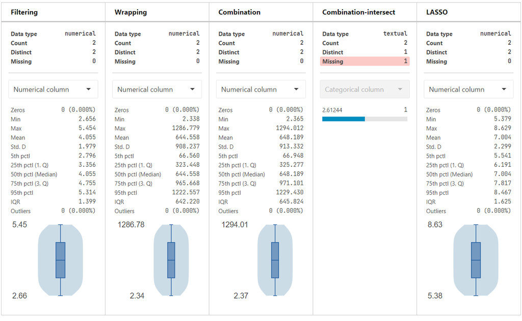

```python
# The below image can be accessed through the datalore 'statistics' section of the above viewed dataframe
img = Image.open('phase1stats.png')
display(img)
```

# Phase 2

## Competition Description

Now you will be given a set of linear models trained on other stations (Station 1 to Station 200) with the training data from a whole year. Although these models are not trained on the stations to be predicted, they can still be used since there should be some similarity among different stations. To successfully use these models can help reuse the knowledge learned from a whole year's data.

The task then is to figure out how to predict the stations in Phase 1 by only using these trained models. Investigate the resulting performances and compare to your own classifiers in Phase 1.

(The pre-trained linear models are given by Models.zip).

## Overview

This phase is broken into the following sections:

- Model Loading
- Model Creation
- Model Selection
- Outputs and Evaluation

In the Model Loading section, a function loads all pre-trained models into a dictionary of dataframes.  
In the Model Creation section, a function is created to take multiple models and output a cumulative model.  
In the Model Selection section, functions are created to select the best model for a station.  
In the Outputs and Evaluation section, functions to perform all tasks are created alongside csv generation and evaluation of the models.

## Model Loading

This section creates a function to load every pre-trained model into a dictionary, on function call the dictionary is returned.

```python
# The function takes no arguments and returns a dictionary of dictionaries containing dataframes
def model_loader():
    # Creates an empty dictionary
    models=dict()
    # For every station (as they are numbered 1 to 200) create a dictionary using the station number, then store each csv in it
    # the dictionary's first key is the station, and second key is the model's name from the csv.
    for i in range(1, 201):
        models[i]=dict()
        models[i]['full']=pd.read_csv(f'Models/model_station_{i}_rlm_full.csv')
        models[i]['full_temp']=pd.read_csv(f'Models/model_station_{i}_rlm_full_temp.csv')
        models[i]['short']=pd.read_csv(f'Models/model_station_{i}_rlm_short.csv')
        models[i]['short_temp']=pd.read_csv(f'Models/model_station_{i}_rlm_short_temp.csv')
        models[i]['short_full']=pd.read_csv(f'Models/model_station_{i}_rlm_short_full.csv')
        models[i]['short_full_temp']=pd.read_csv(f'Models/model_station_{i}_rlm_short_full_temp.csv')
    return models
```

```python
# Uncomment the below code for testing
# model_loader()
```

## Model Creation

This section creates a function for turning a list of models into a single cumulative model, and a function for producing a cumulative model from all the pre-trained models.

```python
# This function takes a list of dataframes and returns a single dataframe
def cumulative_model(models_list):
    try:
        model_values=pd.DataFrame(columns=['feature', 'weight'])
        model_values['feature']=models_list[0]['feature']
        model_values['weight']=models_list[0]['weight']*0
        proportion=1/len(models_list)
        for model in models_list:
            model_values['weight']+=model['weight']*proportion
        return model_values
    except KeyError:
        print("One or more models are not in correct format")
        sys.exit("Error cumulative_model")
```

```python
# Uncomment the below code to test the above function
# cumulative_model([model_loader()[1]['full'], model_loader()[2]['full']]))
```

```python
# As this function is specifically for the pretrained models, it implements model_loader rather than having parameters
def cumulative_pretrained_models():
    # Loads the pre-trained models and creates an empty list for the new models
    models = model_loader()
    models_list = dict()
    # Essentially transposes the models array, setting the model type as the key and the station specific models as the inner dictionary
    for i in models[1].keys():
         models_list[i] = [v.get(i, None) for v in models.values()]

    # Creates an empty dictionary for the cumulative models
    cum_models_list=dict()
    # For every model type (full, short, etc.) pass the list of models to cumulative_models and store the resulting model in the dictionary, using model name as the key
    for i in models_list:
        cum_models_list[i]=cumulative_model(models_list[i])
    return cum_models_list
```

```python
# Uncomment the below code to test the above function
# cumulative_pretrained_models()
```

## Model Selection

This section creates a functions for unpacking pre-trained models, creating custom linear models, and selecting the best pre-trained model for each station. get_model_details converts a pre-trained model into its features, coefficients, and intercept. custom_linearmodel creates a sklearn LinearRegression object using the passed coefficients and intercepts. model_selector implements every pre-trained model on every station to identify the best model for them.

```python
# This function takes a dataframe and returns the features, coefficients, and intercept of the pre-trained model passed to it
def get_model_details(df):
    try:
        # The features are calculated from the feature column, then intercept is omitted
        features = list(df['feature'])
        features.remove('(Intercept)')
        # The coefficients are produced from the weight column, with the first value representing the intercept
        coefficients = df['weight'].to_numpy()
        intercept= coefficients[0]
        coefficients=coefficients[1:]
    # If the dataframe does not contain features and weights, an error is output
    except KeyError:
        print("One or more pre-trained models are not in correct format")
        sys.exit("Error in get_model_details")
    return features, coefficients, intercept
```

```python
# Uncomment the below code to test the above function
# get_model_details(pd.DataFrame({'feature':['(Intercept)','Test'], 'weight': [1,1]}))
```

```python
# This function takes the coefficients and intercept for a model, then returns a LinearRegression object with those values
def custom_linearmodel(coefficients, intercept):
    reg=LinearRegression()
    reg.intercept_=intercept
    reg.coef_= coefficients
    return reg
```

```python
# Uncomment the below code to test the above function
# custom_linearmodel([1,2],3)
```

```python
# The function takes no arguments and returns a dictionary of each station's optimum model
def model_selector():
    # Get all training stations
    df = preprocessing(load_training_data(201, 275))
    # Creates an empty dictionary and loads the pre-trained models using the model_loader
    station_models=dict()
    models=model_loader()
    # For every station in the dataframe, the function finds the optimal model
    for station in list(df['station'].unique()):
        # Sets the current stations dataframe
        station_df=df[(df['station']==station)]
        # Sets the initial r2 value, this is negative incase the best model still has a bad fit
        r2 = -100
        # Creates an empty dataframe for the model to be stored in
        station_models[station]=pd.DataFrame()
        # Goes through every pretrained station and every model within it
        for pretrained_station in models:
            for model in models[pretrained_station]:
                # Gets the features, coefficients, and intercept of the model
                features, coefficients, intercept = get_model_details(models[pretrained_station][model])
                # Gets the features to predict
                station_df_x=station_df[features]
                # Gets the target values for scoring
                station_df_y=station_df['bikes']
                # predicts using a custom model on the values gathered above
                y_pred = custom_linearmodel(coefficients, intercept).predict(station_df_x)
                # Sets a new r2 score, then checks if this is higher than r2. If the score is higher, then new model is stored and r2 is updated
                new_r2 = r2_score(station_df_y, y_pred)
                if new_r2 > r2:
                    r2=new_r2
                    station_models[station]=models[pretrained_station][model]
    return station_models
```

```python
# Uncomment the below code to test the above function
# model_selector(preprocessing(load_training_data(201, 275)))
```

## Modelling

This section creates a single function that has the optional arguments of mode and cum_type. The function will either predict all the test data based on one of the cumulative models (identified by cum_type), or fit every station to using their best pre-trained model.

```python
# The function has two optional arguments, and doesn't return any values; instead, the results are output as a csv file.
def pretrained_modelling(mode="cumulative", cum_type='full'):
    # Reads the csv file of test data
    test=pd.read_csv('test.csv')
    # Creates a bikes column to enable preprocessing
    test['bikes']=0
    # Preprocesses to vectorise days of the week, but does not drop NA values
    test=preprocessing(test, False)

    # If the mode is cumulative, it loads the cumulative pretrained models and uses the specific version to predict the test data
    if mode=='cumulative':
        models= cumulative_pretrained_models()
        features, coefficients, intercept = get_model_details(models[cum_type])
        model = custom_linearmodel(coefficients, intercept)
        model_results= model.predict(test[features])
    # If the mode is specific, model_selector is called and then every station in test.csv is predicted based on the optimal model
    elif mode=='specific':
        model_results=[]
        models=model_selector()
        for station in list(test['station'].unique()):
            station_test=test[(test['station']==station)]
            features, coefficients, intercept = get_model_details(models[station])
            model = custom_linearmodel(coefficients, intercept)
            model_results.extend(model.predict(station_test[features]))
    else:
        print("Incorrect mode input")
        sys.exit("Error during pretrained_modelling")

    # Creates a dataframe from the results, then turns the % of bikes to real numbers and rounds to 0 to make the values whole numbers
    # The results are output as a dataframe stating the type of model created
    results_df = pd.DataFrame({
        'Id': list(test['Id']),
        'bikes': model_results
    })
    results_df['bikes']=results_df['bikes']*test['numDocks']
    results_df = results_df.set_index('Id')
    results_df = results_df.round(0)
    results_df.to_csv(f'submission_{mode}_{cum_type}.csv')
```

```python
# Uncomment the below code to test the above function
# pretrained_modelling('specific')
```

## Outputs and Evaluation

This section contains the code for generating all the models in Phase 2, alongside a quick analysis of the results.  
Uncomment any models you wish to generate the predictions for.

```python
#pretrained_modelling(cum_type='full')
#pretrained_modelling(cum_type='full_temp')
#pretrained_modelling(cum_type='short')
#pretrained_modelling(cum_type='short_temp')
#pretrained_modelling(cum_type='short_full')
#pretrained_modelling(cum_type='short_full_temp')
#pretrained_modelling('specific')
```

```python
# Results manually input from kaggle competition MAE
results=pd.DataFrame({
    'Index': ['Results'],
    'Cumulative full': [3.52444],
    'Cumulative full-temp': [4.54844],
    'Cumulative short': [12.27466],
    'Cumulative short-temp': [13.72177],
    'Cumulative short-full': [3.77777],
    'Cumulative short-full-temp': [4.62222],
    'Cumulative specific': [2.23377]
})
results.set_index('Index', inplace=True)
display(results)
```

| Index | Cumulative full | Cumulative full-temp | Cumulative short | Cumulative short-temp | Cumulative short-full | Cumulative short-full-temp | Cumulative specific |
| --- | --- | --- | --- | --- | --- | --- | --- |
| Results | 3.52444 | 4.54844 | 12.27466 | 13.72177 | 3.77777 | 4.62222 | 2.23377 |

# Phase 3

## Competition Description

Try to achieve an even better performance by designing an approach to combine your own models with the given linear models.

## Overview

This section is broken into the following sections:

- Merging Best Methods
- Exploring Location
- Subgroup Exploration
- Implementing Further Models

Each section aims to understand the data further through exploration.

## Merging Best Methods

```python
# The function takes no arguments and returns a dictionary of each station's optimum model
def improved_model_selector():
    # Get all training stations
    df = preprocessing(load_training_data(201, 275))
    # Creates an empty dictionary and loads the pre-trained models using the model_loader
    station_models=dict()
    models=model_loader()

    #Performs wrapping cumulatively
    wrapping_features=feature_wrapping(df)

    # For every station in the dataframe, the function finds the optimal model
    for station in list(df['station'].unique()):
        # Sets the current stations dataframe
        station_df=df[(df['station']==station)]
        # Sets the initial r2 value, this is negative incase the best model still has a bad fit
        r2 = -100
        # Creates an empty dataframe for the model to be stored in
        station_models[station]=pd.DataFrame()
        # Goes through every pretrained station and every model within it
        for pretrained_station in models:
            for model in models[pretrained_station]:
                # Gets the features, coefficients, and intercept of the model
                features, coefficients, intercept = get_model_details(models[pretrained_station][model])
                # Gets the features to predict
                station_df_x=station_df[features]
                # Gets the target values for scoring
                station_df_y=station_df['bikes']
                # predicts using a custom model on the values gathered above
                y_pred = custom_linearmodel(coefficients, intercept).predict(station_df_x)
                # Sets a new r2 score, then checks if this is higher than r2. If the score is higher, then new model is stored and r2 is updated
                new_r2 = r2_score(station_df_y, y_pred)
                if new_r2 > r2:
                    r2=new_r2
                    station_models[station]=models[pretrained_station][model]

        # Then check wrapping, taken from Phase 2 modelling
        model=LinearRegression()
        station_df_x=station_df[wrapping_features]
        station_df_y=station_df['bikes']
        model.fit(station_df[wrapping_features], station_df['bikes'])
        y_pred = model.predict(station_df_x)
        new_r2 = r2_score(station_df_y, y_pred)
        if new_r2 > r2:
            r2=new_r2
            # Added way to convert model to values, could be stand-alone function
            features_list = ['(Intercept)']
            features_list.extend(wrapping_features)
            coef_list = [model.intercept_]
            coef_list.extend(list(model.coef_))
            station_models[station]=pd.DataFrame({'feature': features_list,
                                                  'weight': coef_list
            })
    return station_models
```

```python
# Uncomment the below code to test the above function
# improved_model_selector()
```

```python
# The function has two optional arguments, and doesn't return any values; instead, the results are output as a csv file.
def improved_pretrained_modelling():
    # Reads the csv file of test data
    test=pd.read_csv('test.csv')
    # Creates a bikes column to enable preprocessing
    test['bikes']=0
    # Preprocesses to vectorise days of the week, but does not drop NA values
    test=preprocessing(test, False)

    # If the mode is cumulative, it loads the cumulative pretrained models and uses the specific version to predict the test data
    # If the mode is specific, model_selector is called and then every station in test.csv is predicted based on the optimal model
    model_results=[]
    models=improved_model_selector()
    for station in list(test['station'].unique()):
        station_test=test[(test['station']==station)]
        features, coefficients, intercept = get_model_details(models[station])
        model = custom_linearmodel(coefficients, intercept)
        model_results.extend(model.predict(station_test[features]))
    # Creates a dataframe from the results, then turns the % of bikes to real numbers and rounds to 0 to make the values whole numbers
    # The results are output as a dataframe stating the type of model created
    results_df = pd.DataFrame({
        'Id': list(test['Id']),
        'bikes': model_results
    })
    results_df['bikes']=results_df['bikes']*test['numDocks']
    results_df = results_df.set_index('Id')
    results_df = results_df.round(0)
    results_df.to_csv(f'submission_improve_specific_full.csv')
```

```python
# Uncomment the below code to test the above function
# improved_pretrained_modelling()
```

```python
display(3.26)
```

```
3.26
```

## Exploring Location

In this section location is explored further; however, it was found that manipulating location did not yield impactful results. First the geography of all stations is visualised, before functions are created to find the distance to the centre of the points, the average distance to the nearest k stations, and the amount of stations within k kilometers. The results of these transformations are depicted in a correlation matrix, and the new dataframes are implemented in feature wrapping to check if the new features are suitable for models.

```python
geographic_view(average_bikes(preprocessing(load_training_data(1,275)), True))
```

```
          latitude  longitude  numDocks     timestamp    year  month  \
station
1        39.476803  -0.380379      20.0  1.413454e+09  2014.0   10.0
2        39.476863  -0.371231      15.0  1.413454e+09  2014.0   10.0
3        39.472766  -0.384174      15.0  1.413454e+09  2014.0   10.0
4        39.474840  -0.379276      20.0  1.413454e+09  2014.0   10.0
5        39.474288  -0.375175      23.0  1.413454e+09  2014.0   10.0
...            ...        ...       ...           ...     ...    ...
271      39.463440  -0.409316      20.0  1.413765e+09  2014.0   10.0
272      39.490257  -0.406462      18.0  1.413765e+09  2014.0   10.0
273      39.494136  -0.406020      16.0  1.413765e+09  2014.0   10.0
274      39.480591  -0.332281      15.0  1.413765e+09  2014.0   10.0
275      39.450273  -0.333363      15.0  1.413765e+09  2014.0   10.0

               day       hour   weekhour  isHoliday  ...  \
```

[output cut: 42 more lines]

Make this Notebook Trusted to load map: File -> Trust Notebook

[interactive chart not shown]

```python
# This function finds the centre of all the points through implementing a kmeans cluster algorithm with 1 centroid, it takes a dataframe as the argument
def find_geocentre(df):
    # Utilise average bikes to get the mean value of longitude and latitude
    average_df = average_bikes(df)
    # Implement KMeans, from sklearn, with 1 clusters
    kmeans = KMeans(n_clusters=1, n_init='auto')
    # Fit the kmeans to the latitude and longitude
    kmeans.fit(average_df[['latitude', 'longitude']])
    return list(kmeans.cluster_centers_)
```

```python
# Uncomment the below code to test the above function
# find_geocentre(preprocessing(load_training_data(1,275)))
```

```python
# This function finds the distance to the centre for every station, it takes a dataframe as the argument
def distance_to_geocentre(df):
    # calls find_geocentre to find the midpoint
    centroid = find_geocentre(df)
    # for every station, find the station's coordinates and then find the WGS-84 distance between them (accounting for earth curvature)
    # store the result as the value for every entry of a station
    # Using geopy as it implements WGS-84 (https://en.wikipedia.org/wiki/Haversine_formula)
    for station in list(df['station'].unique()):
        station_df=df[(df['station']==station)]
        station_coords=list(station_df[['latitude','longitude']].mean())
        station_distance=geopy.distance.geodesic(station_coords, centroid).km
        df.loc[df['station']==station, 'distance_to_geocentre'] = station_distance
    return df
```

```python
# Uncomment the below code to test the above function
# distance_to_geocentre(preprocessing(load_training_data(1,275)))
```

```python
# Calculates the distance between a station and all other stations, then sorts them by distance. Takes a dataframe as the argument
def distance_to_nearest_stations(df):
    # Creates an empty dictionary
    station_distance_dict=dict()
    # For every station create a station dataframe of only that station's values, then create an array of the station's location
    for station in list(df['station'].unique()):
        station_distance=[]
        station_df=df[(df['station']==station)]
        station_coords=list(station_df[['latitude','longitude']].mean())
        # for station pair, find the stations' coordinates and then find the WGS-84 distance between them (accounting for earth curvature)
        # store the results in a list for the station
        # Using geopy as it implements WGS-84 (https://en.wikipedia.org/wiki/Haversine_formula)
        for check_station in list(df['station'].unique()):
            if check_station != station:
                check_station_df=df[(df['station']==check_station)]
                check_station_coords=list(check_station_df[['latitude','longitude']].mean())
                # Using geopy as it implements WGS-84 (https://en.wikipedia.org/wiki/Haversine_formula)
                station_distance.append(geopy.distance.geodesic(station_coords, check_station_coords).km)
        # Sort the values and store them in the dictionary using the station as the key
        station_distance.sort()
        station_distance_dict[station]=station_distance
    return station_distance_dict
```

```python
# Uncomment the below code to test the above function
# distance_to_nearest_stations(preprocessing(load_training_data(1,275)))+
```

```python
# Finds the average distance between k stations, requires a dataframe, list of station distances in order, and a k value (defaulted to 1)
def average_distance_to_nearest_k_stations(df, station_distances, k=1):
    # For every station go through the first k values of the list of distances, dividing each value by k to find the average
    for station in list(df['station'].unique()):
        average_k_station_distance=0
        for i in range(k):
            average_k_station_distance+=station_distances[station][i]/k
        # Store the distance as the value for every entry of a station
        df.loc[df['station']==station, f'nearest_{k}_stations_dist'] = average_k_station_distance
    return df
```

```python
# Uncomment the below code to test the above function
# average_distance_to_nearest_k_stations(preprocessing(load_training_data(1,275)), distance_to_nearest_stations(preprocessing(load_training_data(1,275))))
```

```python
# Finds the number of stations with k km, requires a dataframe, list of station distances in order, and a k value (defaulted to 0.25)
def stations_within_k_km(df, station_distances, k=0.25):
    # for every station, go through the distances and add 1 to the count for every distance below or equal to k.
    # Assumes order, so breaks on first value that doesn't meet the condition
    for station in list(df['station'].unique()):
        number_stations=0
        for i in range(len(station_distances[station])):
            if station_distances[station][i] <=0.25:
                number_stations+=1
            else:
                break
        # Store the distance as the value for every entry of a station
        df.loc[df['station']==station, f'stations_within_{k}_km'] = number_stations
    return df
```

```python
# Uncomment the below code to test the above function
# stations_within_k_km(preprocessing(load_training_data(1,275)), distance_to_nearest_stations(preprocessing(load_training_data(1,275))))
```

```python
# Function that runs all the 'Exploring Location' functions and returns the dataframe
def exploring_location(df):
    station_distances = distance_to_nearest_stations(df)
    df = distance_to_geocentre(df)
    df = stations_within_k_km(df, station_distances)
    for i in range(5):
        df = average_distance_to_nearest_k_stations(df, station_distances, i+1)
    return df
```

```python
# Uncomment the below code to test the above function
# exploring_location(preprocessing(load_training_data(1,275)))
```

```python
# Modified correlation function that reduces the values shown, requires a average_distance_to_nearest_k_stations for 1-5
def simple_location_correlation_matrix(df, show=False):
    df=df[['latitude', 'longitude', 'numDocks', 'bikes_3h_ago', 'full_profile_3h_diff_bikes', 'short_profile_3h_diff_bikes', 'full_profile_bikes', 'short_profile_bikes', 'bikes', 'distance_to_geocentre', 'nearest_1_stations_dist', 'nearest_2_stations_dist', 'nearest_3_stations_dist', 'nearest_4_stations_dist', 'nearest_5_stations_dist', 'stations_within_0.25_km']]
    # Uses pandas corr() to get correlation matrix
    correlation=df.corr()
    # If the function is called to show the function
    if show:
        # Sets figure size
        plt.figure(figsize=(20, 10))
        # Plots the heatmap, with 1 and -1 as boundaries and annotations. FMT rounds the values in the figure
        plot=sb.heatmap(correlation,  cmap="YlGnBu",vmin=-1, vmax=1, annot=True, fmt=".2f")
        # Adds a title
        plot.set_title('Correlation Heatmap', fontdict={'fontsize':18}, pad=12)
        # Saves the map as heatmap.png for later viewing.
        plt.savefig('simple_heatmap.png', dpi=300, bbox_inches='tight')
    return correlation
```

|  | latitude | longitude | numDocks | bikes_3h_ago | full_profile_3h_diff_bikes | short_profile_3h_diff_bikes | full_profile_bikes | short_profile_bikes | bikes | distance_to_geocentre | nearest_1_stations_dist | nearest_2_stations_dist | nearest_3_stations_dist | nearest_4_stations_dist | nearest_5_stations_dist | stations_within_0.25_km |
| --- | --- | --- | --- | --- | --- | --- | --- | --- | --- | --- | --- | --- | --- | --- | --- | --- |
| latitude | 1.000000 | -0.134558 | -0.019958 | -0.140002 | -0.000002 | 0.000064 | -0.248473 | -0.195587 | -0.139949 | 0.046926 | 0.044670 | 0.061238 | 0.033212 | 0.019192 | 0.012553 | -0.039158 |
| longitude | -0.134558 | 1.000000 | 0.198852 | 0.216572 | 0.000097 | 0.000918 | 0.324791 | 0.210502 | 0.216655 | 0.015600 | -0.173437 | -0.195080 | -0.160594 | -0.143028 | -0.130643 | 0.108470 |
| numDocks | -0.019958 | 0.198852 | 1.000000 | -0.143889 | 0.001580 | 0.001284 | -0.182501 | -0.195397 | -0.143243 | -0.223029 | -0.392536 | -0.299922 | -0.270895 | -0.254004 | -0.246160 | 0.470361 |
| bikes_3h_ago | -0.140002 | 0.216572 | -0.143889 | 1.000000 | -0.232694 | -0.244500 | 0.475698 | 0.451505 | 0.678960 | 0.153801 | 0.072238 | 0.033434 | 0.039563 | 0.043197 | 0.049235 | -0.142489 |
| full_profile_3h_diff_bikes | -0.000002 | 0.000097 | 0.001580 | -0.232694 | 1.000000 | 0.871116 | 0.369663 | 0.352138 | 0.263766 | -0.002281 | -0.001334 | -0.001056 | -0.001075 | -0.001122 | -0.001188 | 0.001321 |
| short_profile_3h_diff_bikes | 0.000064 | 0.000918 | 0.001284 | -0.244500 | 0.871116 | 1.000000 | 0.312002 | 0.392555 | 0.262511 | -0.001694 | -0.000832 | -0.000532 | -0.000416 | -0.000435 | -0.000484 | 0.000900 |
| full_profile_bikes | -0.248473 | 0.324791 | -0.182501 | 0.475698 | 0.369663 | 0.312002 | 1.000000 | 0.873589 | 0.646214 | 0.204242 | 0.135493 | 0.074712 | 0.071045 | 0.070768 | 0.075675 | -0.191238 |
| short_profile_bikes | -0.195587 | 0.210502 | -0.195397 | 0.451505 | 0.352138 | 0.392555 | 0.873589 | 1.000000 | 0.642296 | 0.183947 | 0.114036 | 0.050962 | 0.046381 | 0.045245 | 0.051879 | -0.194993 |
| bikes | -0.139949 | 0.216655 | -0.143243 | 0.678960 | 0.263766 | 0.262511 | 0.646214 | 0.642296 | 1.000000 | 0.152510 | 0.071453 | 0.032804 | 0.039053 | 0.042739 | 0.048800 | -0.141641 |
| distance_to_geocentre | 0.046926 | 0.015600 | -0.223029 | 0.153801 | -0.002281 | -0.001694 | 0.204242 | 0.183947 | 0.152510 | 1.000000 | 0.498209 | 0.516526 | 0.548141 | 0.560127 | 0.578805 | -0.313437 |
| nearest_1_stations_dist | 0.044670 | -0.173437 | -0.392536 | 0.072238 | -0.001334 | -0.000832 | 0.135493 | 0.114036 | 0.071453 | 0.498209 | 1.000000 | 0.883601 | 0.795692 | 0.745018 | 0.718233 | -0.659941 |
| nearest_2_stations_dist | 0.061238 | -0.195080 | -0.299922 | 0.033434 | -0.001056 | -0.000532 | 0.074712 | 0.050962 | 0.032804 | 0.516526 | 0.883601 | 1.000000 | 0.968816 | 0.936948 | 0.913767 | -0.478593 |
| nearest_3_stations_dist | 0.033212 | -0.160594 | -0.270895 | 0.039563 | -0.001075 | -0.000416 | 0.071045 | 0.046381 | 0.039053 | 0.548141 | 0.795692 | 0.968816 | 1.000000 | 0.991643 | 0.979736 | -0.388097 |
| nearest_4_stations_dist | 0.019192 | -0.143028 | -0.254004 | 0.043197 | -0.001122 | -0.000435 | 0.070768 | 0.045245 | 0.042739 | 0.560127 | 0.745018 | 0.936948 | 0.991643 | 1.000000 | 0.995920 | -0.343126 |
| nearest_5_stations_dist | 0.012553 | -0.130643 | -0.246160 | 0.049235 | -0.001188 | -0.000484 | 0.075675 | 0.051879 | 0.048800 | 0.578805 | 0.718233 | 0.913767 | 0.979736 | 0.995920 | 1.000000 | -0.324494 |
| stations_within_0.25_km | -0.039158 | 0.108470 | 0.470361 | -0.142489 | 0.001321 | 0.000900 | -0.191238 | -0.194993 | -0.141641 | -0.313437 | -0.659941 | -0.478593 | -0.388097 | -0.343126 | -0.324494 | 1.000000 |

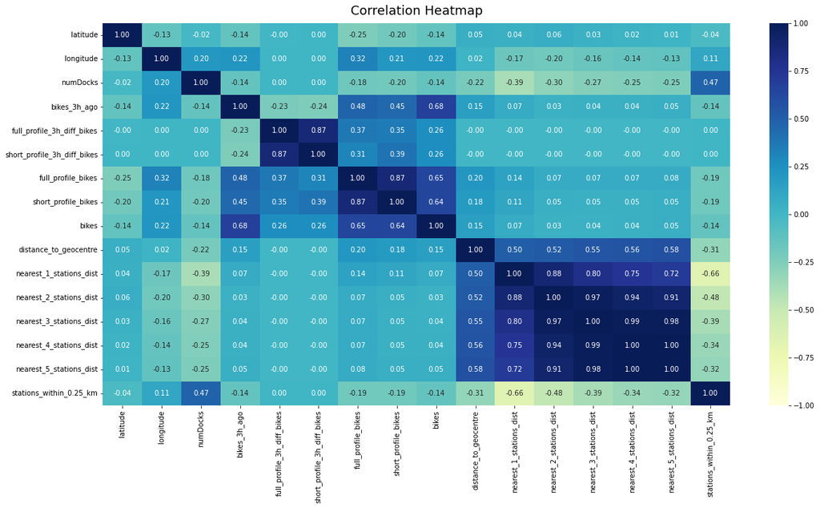

```python
# Uncomment the below code to test
simple_location_correlation_matrix(exploring_location(preprocessing(load_training_data(1,275))), True)
```

```python
# Uncomment the below code to test
feature_wrapping(exploring_location(preprocessing(load_training_data(1,275))))
```

```
['bikes_3h_ago',
 'full_profile_3h_diff_bikes',
 'full_profile_bikes',
 'short_profile_3h_diff_bikes']
```

## Subgroup Exploration

This section explores subgroups within the data through visualisation.

```python
# Takes two arguments, a dataframe and optional show. Returns a tree and its features (x value it was trained on)
def create_tree(df, show=False):
    # Sets y to bikes
    y = df['bikes']
    # Uses feature wrapping to reduce the features, then trains the tree model on the features
    features = list(feature_wrapping(df))
    x = df[features]
    # Create a decision tree regressor
    tree = DecisionTreeRegressor()
    # Fit the decision tree on your data
    tree.fit(x, y)
    # If show, create a figure from the tree
    if show:
        fig, ax = plt.subplots(figsize=(10, 6))
        plot_tree(tree, filled=True, feature_names=features, ax=ax)
        fig.show()
        plt.savefig('subgroups.png', dpi=300, bbox_inches='tight')
    return tree, x
```

```python
import numpy as np

# Code from https://github.com/scikit-learn/scikit-learn/issues/20428
def export_dict(tree, feature_names=None):
    if feature_names is None:
        feature_names = range(tree.max_features_)

    # Build tree nodes
    tree_nodes = []
    for i in range(tree.node_count):
        if tree.children_left[i] == tree.children_right[i]:
            tree_nodes.append(
                tree.classes_[np.argmax(tree.value[i])]
            )
        else:
            tree_nodes.append({
                "feature": feature_names[tree.feature[i]],
                "value": tree.threshold[i],
                "left": tree.children_left[i],
                "right": tree.children_right[i],
            })

    # Link tree nodes
    for node in tree_nodes:
        if isinstance(node, dict):
            node["left"] = tree_nodes[node["left"]]
        if isinstance(node, dict):
            node["right"] = tree_nodes[node["right"]]

    # Return root node
    return tree_nodes[0]
```

```python
# Takes a datafrane and show to pass to create_tree
def get_subgroups(df, show=False):
    # Creates a tree and identifies the first nodes
    tree, features = create_tree(df, show)
    tree_ = tree.tree_
    # Gets the subgroups through the export_dict function, then prints the subgroups out
    # Commented out due to computational requirements
    # export_dict(tree_, features.columns)
    print("Extracted Subgroups:")
    for subgroup, prediction in subgroups:
        print(f"Subgroup Condition: {subgroup}, Predicted Value: {prediction}")
```

```python
get_subgroups(preprocessing(load_training_data(200,275)), True)
```

[output not shown]

[output not shown]

[figure not shown]

```python
# The below image can be accessed through the datalore 'get_tree' show
img = Image.open('subgroups.png')
display(img)
```

## Implementing Further Models

In this wrap-up section, a method for implementing different regression models is created. Alternative regression models are ran through the function.

```python
# Function takes a dataframe and the regressor
def model_regression(df, regr):
    # Identifies the standard target variables and features from earlier
    target_column = 'bikes'
    features=df.drop(columns=[target_column])
    # Fits the model to the features and target column
    regr.fit(features, df[target_column])
    # Reads the csv file of test data
    test=pd.read_csv('test.csv')
    # Creates a bikes column to enable preprocessing
    test['bikes']=0
    # Preprocesses to vectorise days of the week, but does not drop NA values
    test=preprocessing(test, False)
    # creates a second test df for organising the results
    test_2=test.drop(columns=['bikes', 'Id'])
    # Predicts using the regression
    pred = regr.predict(test_2)
    # Standard results format from earlier, with csv named after regressor and parameters
    results_df = pd.DataFrame({
        'Id': list(test['Id']),
        'bikes': pred
    })
    results_df['bikes']=results_df['bikes']*test['numDocks']
    results_df = results_df.set_index('Id')
    results_df = results_df.round(0)
    results_df.to_csv(f'submission_{str(regr)}.csv')
```

```python
#from sklearn.ensemble import RandomForestRegressor
#model_regression(preprocessing(load_training_data(200,275)), RandomForestRegressor(max_depth=2, random_state=0))
#from sklearn.ensemble import GradientBoostingRegressor
#model_regression(preprocessing(load_training_data(200,275)), GradientBoostingRegressor(random_state=0))
#from sklearn.linear_model import Ridge
#model_regression(preprocessing(load_training_data(200,275)), Ridge(alpha=.5))
#from sklearn.svm import SVR
#model_regression(preprocessing(load_training_data(200,275)), SVR())
```

```python
# Results manually input from kaggle competition MAE
results=pd.DataFrame({
    'Index': ['Results'],
    'RandomForest': [3.14222],
    'GradientBoostingRegressor': [2.16266],
    'Ridge': [75.78044],
    'SVR': [5.35377],
})
results.set_index('Index', inplace=True)
display(results)
```

| Index | RandomForest | GradientBoostingRegressor | Ridge | SVR |
| --- | --- | --- | --- | --- |
| Results | 3.14222 | 2.16266 | 75.78044 | 5.35377 |